# S5_P4 Infome

Para esto realizaremos una prueba de hipótesis de diferencia de medias debido a que hemos separado a la muestra de toda la población en la muestra de los que se quedan en la empresa y la muestra de los que realizan la fuga de clientes.Y con una distribución normal, realizando la prueba Z, debido a que la muestra es mayor a 30,varianzas desconocidas y diferentes.

**PLANTEAMIENTO DE HIPÓTESIS**

- Hipótesis Nula: El costo promedio en la mañana de los clientes que dejaron la empresa telefónica menos el promedio de los clientes que permanecen en la empresa telefónica es mayor a 0.
- Hipótesis Alternativa: El costo promedio en la mañana de los clientes que dejaron la empresa telefónica menos el promedio de los clientes que permanecen en la empresa telefónica es menor a 0.

- Determinamos un nivel de confianza del 95% y nivel de significancia del 5% (alfa=0.05)
  - Primero determinamos que según el planteamiento de la hipotesis, se hará una prueba de cola inferior y con ello determinar si el estadístico de prueba esta dentro o fuera de la región de rechazo.
  - Valor crítico (Zcrítico) con el cual lograremos determinar la región de rechazo.Con un nivel de significancia de 5%.

```r
Zcr2<-qnorm(0.05)
Zcr2
```

```
## [1] -1.644854
```

- Zona de rechazo es determinada por el valor crítico.

```r
ZR2<-pnorm(Zcr2)
ZR2
```

```
## [1] 0.05
```

```r
X3 <- mean(DF_salen$M_tarifa) #x tarifa que salen
X4<- mean(DF_quedan$M_tarifa) #x tarifa quedan
s3<-sd(DF_salen$M_tarifa)
s4<-sd(DF_quedan$M_tarifa)
Zprueba2 <- (X3 - X4)/sqrt(((s3^2)/n3)+ ((s4^2)/n4))
Zprueba2
```

```
## [1] 9.684476
```

**Regla de discusión**

Con la gráfica a continuación podremos observar si el estadístico es mayor al valor crítico para un nivel de significancia del 5%, para determinar el rechazo o no rechazo de la hipótesis.

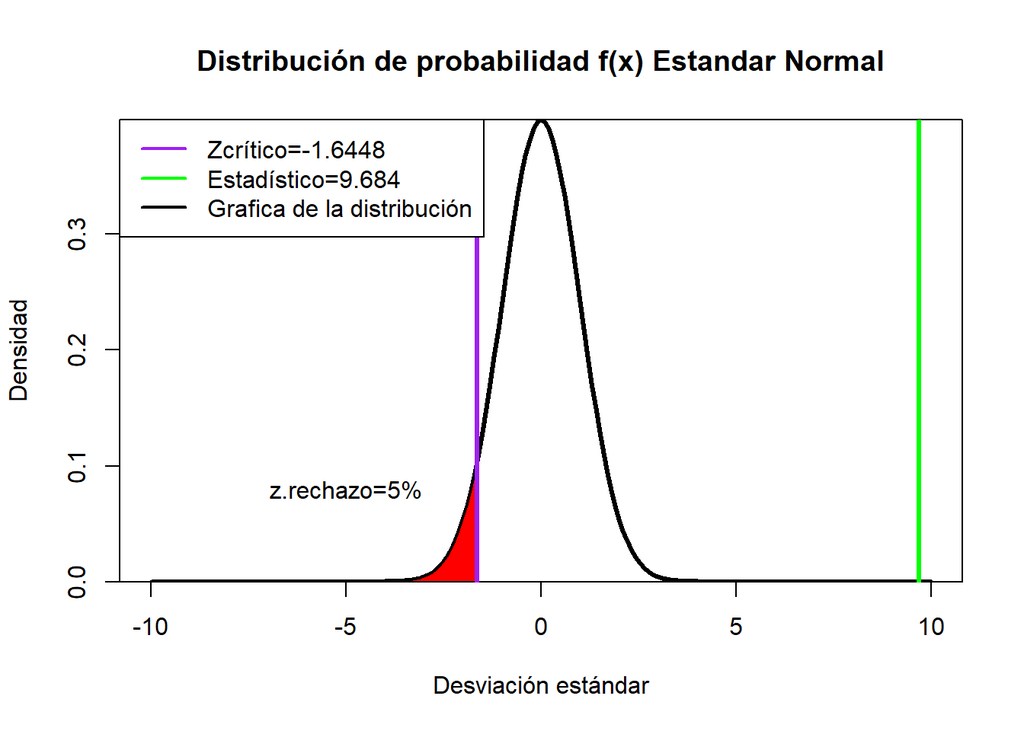

```r
x<-seq(-10,10,0.1)
hist <- dnorm(x, mean=0, sd=1)
plot(x, hist, type="l", xlab="Desviación estándar", ylab="Densidad",main="Distribución de probabilidad f(x) Estandar Normal", lty = 1, lwd = 3, yaxs="i") #yaxs="i" localiza en el eje el límite del dato
polygon(c(x[x <=Zcr2], Zcr2), c(dnorm(x[x <= Zcr2]), 0), col="red")
text(-5,0.08,"z.rechazo=5%")
abline(v=Zcr2,col='purple',lwd=3)
abline(v=Zprueba2,col='green',lwd=3)
legend( x = "topleft",legend = c("Zcrítico=-1.6448","Estadístico=9.684","Grafica de la distribución"), col = c("purple","green","black"),lwd = 2)
```

- Con lo hallado anteriormente podemos decir que nuestra hipótesis será no rechazada porque el Z del estadístico es mayor al Zcrítico nivel de significancia (0.05) que fue dado por el nivel de confianza y con ello estaría fuera de la zona de rechazo.Por lo tanto podemos decir que lo deducido en los bloxplot del inicio es congruente con lo encontrado y que no estaba errado el fórmular esta hipótesis.Es decir, no podemos rechazar que la media del costo en la mañana de los que salen de la compañía es mayor a la de los que se quedaron, pudiendo ser un posible factor de la fuga.

**Análisis descriptivo 3**

- Se podrá observar los patrones de las variables a estudiar que nos serán útiles para poder plantear nuestras hipótesis. Se utilizará descriptores gráficos y numéricos, así como también los parámetros del estudio (nivel de confianza, precisión y tamaño de la muestra.

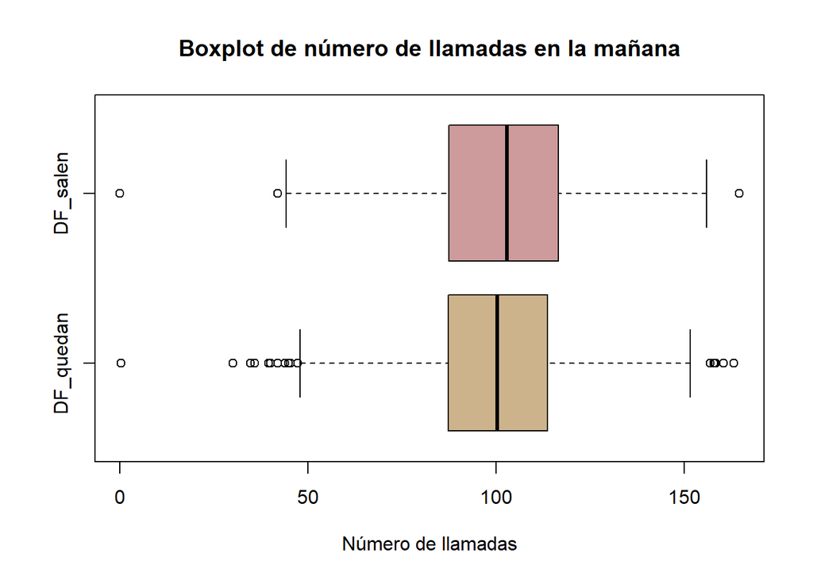

```r
boxplot(  DF_quedan$M_llamadas
        , DF_salen$M_llamadas
        , main = "Boxplot de número de llamadas en la mañana"
        , col = c( "navajowhite3", "rosybrown3")
        , xlab = "Número de llamadas"
        , names = c("DF_quedan", "DF_salen")
        , horizontal = TRUE
        )
```

- Notamos que la mediana en los que salen es mayor a los que se quedan.
- Se hallará el intervalo de confianza de la diferencia de medias del Data Frame de los clientes que abandonan la empresa telefónica y del Data Frame de los clientes que permanecen en la empresa telefónica.
- Teniendo un nivel de confianza al 95%, significancia de 5% y priorizando la confianza en consecuencia primero se hallará la media muestral de cada una y el tamaño de las muestras: **Media muestral y tamaño de muestra de las llamadas en la mañana de los que salen de la operadora**.

```r
media5 <- mean(DF_salen$M_llamadas) #media muestral
n5 <- length(DF_salen$M_llamadas)   #tamaño de la muestra
```

- Media muestral y tamaño de muestra de las llamadas en la mañana de los que se quedan en la operadora.

```r
media6 <- mean(DF_quedan$M_llamadas) #media muestral
n6<- length(DF_quedan$M_llamadas)   #tamaño de muestra
```

```r
z <- qnorm((1-0.95)/2)       #95%

#al no tener la desviación estándar poblacional usaremos la sd muestral
desviacion5 <- sd(DF_salen$M_llamadas)
desviacion6 <- sd(DF_quedan$M_llamadas)

#error estandar
errorst5 <- sqrt(((desviacion5^2)/n5)+((desviacion6^2)/n6))

#limite inferior
lim_inf5 <- (media5-media6) +(z*errorst5)

#limite superior
lim_sup5 <- (media5-media6) -(z*errorst5)

interval_m5 <- data.frame( media5-media6, desviacion5,desviacion6,z, errorst5, lim_inf5, lim_sup5)
interval_m5
```

| media5...media6 | desviacion5 | desviacion6 | z | errorst5 | lim_inf5 | lim_sup5 |
| --- | --- | --- | --- | --- | --- | --- |
| 1.066714 | 21.59198 | 19.79923 | -1.959964 | 1.050139 | -0.9915218 | 3.124949 |

- Se hallará la precisión de la diferencia de medias.

```r
#Precisión
precision5 <- -z*errorst5
precision5
```

```
## [1] 2.058235
```

- Se hallará el tamaño de la muestra de las personas que abandonan la empresa telefónica.

```r
length(DF_salen$M_llamadas)
```

```
## [1] 483
```

- Se hallará el tamaño de la muestra de las personas que permanecen en la empresa telefónica.

```r
length(DF_quedan$M_llamadas)
```

```
## [1] 2850
```

- Se puede visualizar que los intervalos de confianza que se obtuvieron concuerda con lo que se puede observar en el boxplot. A partir de ello, crearemos una hipótesis que nos ayudará a verificar de manera exacta si es que existe una relación entre las variables de número de llamadas en la mañana con la permanencia del cliente en la empresa telefónica.

**Hipótesis 3**

Se intenta comprobar una relación que puede existir entre el número de las llamadas en las mañanas y la permanencia en el servicio. Para ello se usará los data frame DF_quedan y DF_salen para compararlos. Con este estudio queremos validar si es que existe esta relación para determinar la causa de fuga de clientes. Para esto realizaremos una prueba de hipótesis de diferencia de medias debido a que hemos separado a la muestra de toda la población en la muestra de los que se quedan en la empresa y la muestra de los que realizan la fuga de clientes.Y con una distribución normal, realizando la prueba Z, debido a que la muestra es mayor a 30,varianzas desconocidas y diferentes.

**PLANTEAMIENTO DE HIPÓTESIS**

-Hipótesis nula: El numero promedio de las llamadas en la mañana de los que se van menos el numero promedio de estas llamadas de los que se quedan es mayor a 0.

-Hipótesis alternativa: El numero promedio de las llamadas en la mañana de los que se van menos el numero promedio de estas llamadas de los que se quedan es menor a 0.

$${Siendo}\
\mu_1:{la~media~de~llamadas~de~al~operador~de~las~personas~que~salen~de~la~operadora~y}\\
\\\mu_2:{Media~de~las~llamadas~al~operador~de~las~personas~que~se~quedan}$$

$$H_{0}:\mu_{1} - \mu_{2} \geq
{0}$$
$$H_{a}:\mu_{1} - \mu_{2} <
{0}$$

- Primero determinamos que según el planteamiento de la hipótesis, se hará una prueba de cola inferior y con ello determinar si el estadístico de prueba esta dentro o fuera de la región de rechazo.
- Valor crítico (Zcrítico) con el cual lograremos determinar la región de rechazo.Con un nivel de significancia de 5%.

```r
Zcr3<-qnorm(0.05)
Zcr3
```

```
## [1] -1.644854
```

- Zona de rechazo es determinada por el valor crítico.

```r
ZR3<-pnorm(Zcr3)
ZR3
```

```
## [1] 0.05
```

- Se hallará el estadístico de prueba de cada uno de los Data Frame con respecto al número de llamadas en la mañana y el costo total.

```r
X5 <- mean(DF_salen$M_llamadas, na.rm = TRUE) #x muestra salen
X6 <- mean(DF_quedan$M_llamadas, na.rm = TRUE) #x muestra quedan

s5 <- sd(DF_salen$M_llamadas, na.rm = TRUE) #des salen
s6 <- sd(DF_quedan$M_llamadas, na.rm = TRUE) #des quedan

Zprueba3 <-(X5-X6)/sqrt(((s5^2)/n5)+((s6^2)/n6))
Zprueba3
```

```
## [1] 1.015783
```

**Regla de discusión**

Con la gráfica a continuación podremos observar si el estadístico es mayor al valor crítico para un nivel de significancia del 5%, para determinar el rechazo o no rechazo de la hipótesis.

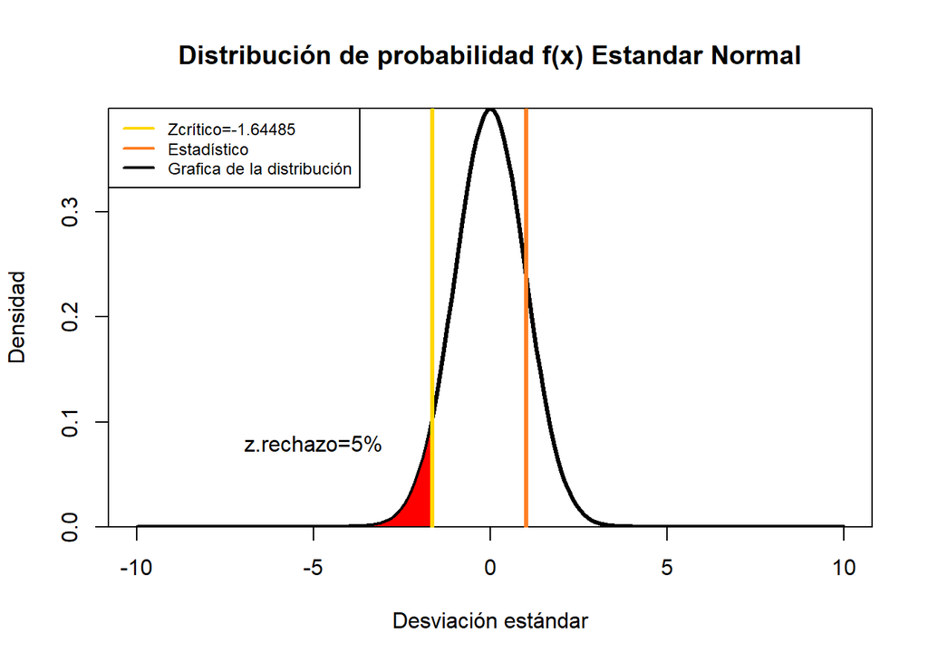

```r
x<-seq(-10,10,0.1)
hist <- dnorm(x, mean=0, sd=1)
plot(x, hist, type="l", xlab="Desviación estándar", ylab="Densidad",main="Distribución de probabilidad f(x) Estandar Normal", lty = 1, lwd = 3, yaxs="i") # yaxs="i" localiza en el eje el límite del dato
polygon(c(x[x <=Zcr3], Zcr3), c(dnorm(x[x <= Zcr3]), 0), col="red")
text(-5,0.08,"z.rechazo=5%")
abline(v=Zcr3,col='#FFD700',lwd=3)
abline(v=Zprueba3,col="#FF7F24",lwd=3)
legend( x = "topleft",legend = c("Zcrítico=-1.64485","Estadístico","Grafica de la distribución"), col = c("#FFD700","#FF7F24","black"),lwd = 2,cex=0.75)
```

- Con lo hallado anteriormente podemos decir que nuestra hipótesis será no rechazada porque el Z del estadístico es mayor al Zcrítico nivel de significancia (0.05) que fue dado por el nivel de confianza y con ello estaría fuera de la zona de rechazo.Por lo tanto podemos decir que lo deducido en los bloxplot del inicio es congruente con lo encontrado y que no estaba errado el fórmular esta hipótesis.Es decir, no podemos rechazar que el número de llamadas en la mañana de los que salen de la compañía son mayores a las que se quedaron.

### **Regresiones**

El departamento de marketing de la empresa telefónica AT&T desea realizar un estudio sobre las relaciones entre variables tanto en el Data Frame de las personas que permanecen en la empresa como las personas que abandonan la empresa. Por lo que han seleccionado un grupo de clientes que sean de interés para cada una de las relaciones.

CAMBIO DE LAS VARIABLES DISCRETAS EDAD, OPERADOR Y M_llamadas A CONTINUAS

```r
#write.csv(DF,"churn7.csv", row.names = FALSE)
#ruido_edad <- r(runif(3333, min=-0.4, max=0.4))
#DF$edad <- DF$edad + ruido_edad
#ruido_operador <- r(runif(3333, min=-0.4, max=0.4))
#DF$operador <- ifelse (DF$operador + ruido_operador>0 , DF$operador + ruido_operador, 0)
#ruido_mllamadas <- r(runif(3333, min=-0.4, max=0.4))
#DF$M_llamadas <- DF$M_llamadas + ruido_mllamadas
```

**Regresión 1**

En la siguiente regresión se muestra la relación entre las variables M_mins (minutos en la mañana) que es la variable dependiente “Y”, y la variable edad que será la variable independiente “X”. Se selecciona cierta parte de la población

**Restricción de datos:**

Para la aplicacion de busqueda de informacion, el area de marketing de la empresa determino y selecciono a un grupo de usuarios específicos para este análisis, los cuales cumplen con los siguientes parámetros:

```r
DF_filt1 <-DF_salen[(DF_salen$M_mins>70) & (DF_salen$M_mins>175 | DF_salen$edad>47) & (DF_salen$M_mins>260 | DF_salen$edad>35) & (DF_salen$M_mins<240 | DF_salen$edad<42),]
```

**Correlación entre las variables:**

```r
cor(DF_filt1$M_mins, DF_filt1$edad)
```

```
## [1] -0.7096973
```

**Coeficientes de regresión:**

- Se aplica la función lm, que ajusta una nube de puntos a un modelo lineal.

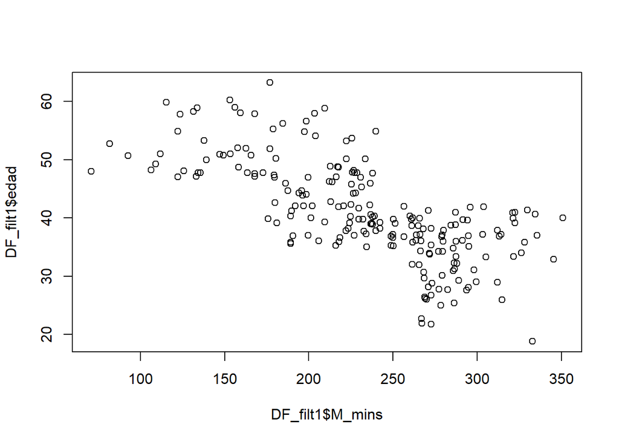

```r
lmf_mm_er <- lm(DF_filt1$M_mins ~  DF_filt1$edad)
# Creamos el gráfico
plot(DF_filt1$M_mins, DF_filt1$edad)
```

- Se aplica la función summary a la variable de regresión y se extraen los coeficientes estimados para el intercepto (ßo) y para la variable (ß1). Además se halla el intervalo de la variable edad.

```r
summary(lmf_mm_er)
```

```
##
## Call:
## lm(formula = DF_filt1$M_mins ~ DF_filt1$edad)
##
## Residuals:
##      Min       1Q   Median       3Q      Max
## -129.031  -25.879    0.299   25.086  112.861
##
## Coefficients:
##               Estimate Std. Error t value Pr(>|t|)
## (Intercept)   428.6229    13.7535   31.16   <2e-16 ***
## DF_filt1$edad  -4.7635     0.3279  -14.53   <2e-16 ***
## ---
## Signif. codes:  0 '***' 0.001 '**' 0.01 '*' 0.05 '.' 0.1 ' ' 1
##
## Residual standard error: 40.75 on 208 degrees of freedom
## Multiple R-squared:  0.5037, Adjusted R-squared:  0.5013
## F-statistic: 211.1 on 1 and 208 DF,  p-value: < 2.2e-16
```

```r
min(DF_filt1$edad)
```

```
## [1] 18.81
```

```r
max(DF_filt1$edad)
```

```
## [1] 63.23
```

$y : minutos$ $x : edad $ $y(x)=\beta_0 + \beta_1x$ $y(x)= 428.6229 - 4.7635; x\in[19;63]$

El R-cuadrado que resulta del modelo es 0.5 por lo que es medianamente bueno el ajuste del modelo lineal. Lo que significa que los datos de la muestra elegida por el departamento de marketing, del Data Frame de las personas que abandonan la empresa, están medianamente cerca de la línea de regresión ajustada. Mi modelo y estimado explica el 50.37% de la variación total de las variables.

**Prueba de hipótesis para la validez del modelo**

$$H_{0}:{El~modelo~no~es~válido}$$
$$H_{a}:{El~modelo~es~válido}$$

Rechazamos la hipótesis nula puesto que el p-value es menor que 2.2e-16 por lo que será menor que el α. Como estamos trabajando al 95% de confianza, el valor de α = 0.05. Por ende, el modelo es válido.

**Prueba de hipótesis para verificar el aporte de x**

**Regresión 2**

En la siguiente regresión se muestra la relación entre la variable costo en la mañana (M_costo) que representará la variable independiente “x” y la variable promedio de llamadas al operador (operador) que será la variable dependiente “y” de usuarios específicos seleccionados del dataframe DF por la dirección de marketing de la empresa, ya que son el foco de interés, .

**Restricción de datos:**

```r
DFCorR2_salen <- DF_salen[(DF_salen$M_tarifa>35 | DF_salen$operador>2.3) & (DF_salen$operador<7), ]
```

**Correlación entre las variables:**

```r
correlacionR2 <- cor(DFCorR2_salen$M_tarifa, DFCorR2_salen$operador)
correlacionR2
```

```
## [1] -0.6907337
```

La correlación entre las variables es -0.6907337, la cual es negativa. Esto indica que presentan una proporcionalidad inversa. Se considera que la correlación entre estas variables es fuerte ya que es cercano a 0.7.

**Coeficientes de regresión:** Se aplica la función lm, que ajusta una nube de puntos a un modelo lineal.

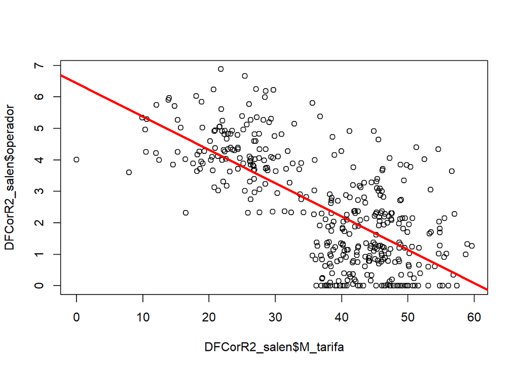

```r
modeloR2 <- lm(DFCorR2_salen$operador ~ DFCorR2_salen$M_tarifa)

# Creamos el gráfico
plot(DFCorR2_salen$M_tarifa, DFCorR2_salen$operador)

# Línea de regresión
abline(modeloR2, col = "red", lwd = 3)

# Correlación de Pearson
text(paste("Correlación:", round(correlacionR2, 2)), x = 25, y = 95)
```

```r
summary(modeloR2)
```

```
##
## Call:
## lm(formula = DFCorR2_salen$operador ~ DFCorR2_salen$M_tarifa)
##
## Residuals:
##     Min      1Q  Median      3Q     Max
## -2.6086 -0.9113 -0.0630  0.8126  3.6809
##
## Coefficients:
##                         Estimate Std. Error t value Pr(>|t|)
## (Intercept)             6.439711   0.221286   29.10   <2e-16 ***
## DFCorR2_salen$M_tarifa -0.105891   0.005642  -18.77   <2e-16 ***
## ---
## Signif. codes:  0 '***' 0.001 '**' 0.01 '*' 0.05 '.' 0.1 ' ' 1
##
## Residual standard error: 1.28 on 386 degrees of freedom
## Multiple R-squared:  0.4771, Adjusted R-squared:  0.4758
## F-statistic: 352.2 on 1 and 386 DF,  p-value: < 2.2e-16
```

- Se aplica la función summary a la variable de regresión y se extraen los coeficientes estimados para el intercepto (ßo) y para la variable x (ß1). ßo = 6.439711 ß1 = -0.105891

y(x)=ß0+ß1x

y(x)=6.439711-0.105891x ; x∈[0;60]

```r
min(DFCorR2_salen$M_tarifa)
```

```
## [1] 0
```

```r
max(DFCorR2_salen$M_tarifa)
```

```
## [1] 59.64
```

$y(x)=\beta_0 + \beta_1x$ $y(x)= 6.439711 - 0.105891x; x\in[0;59.64]$

- Ploteamos el modeloR2

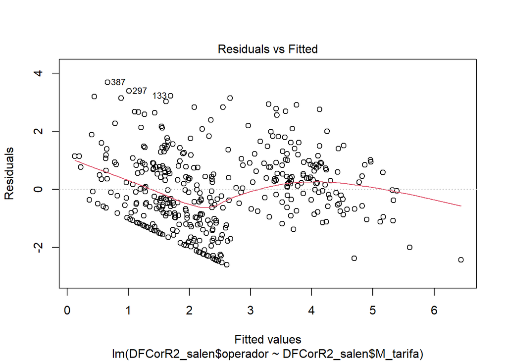

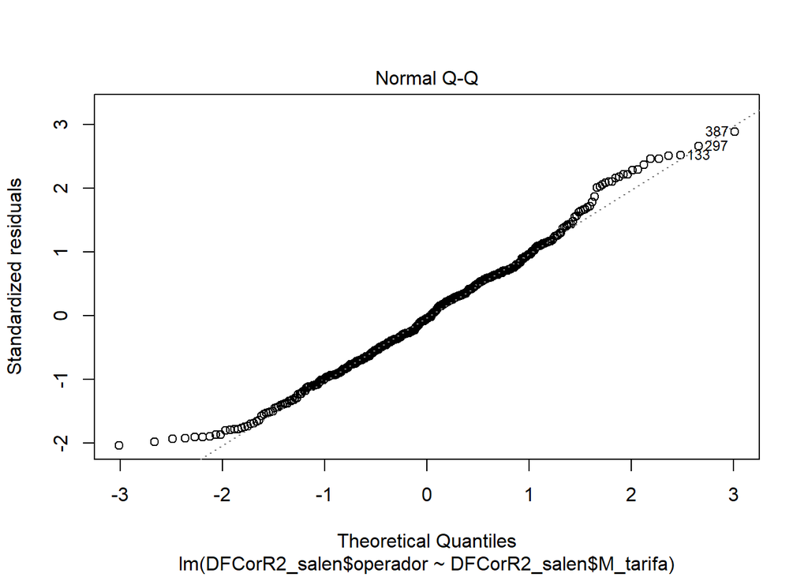

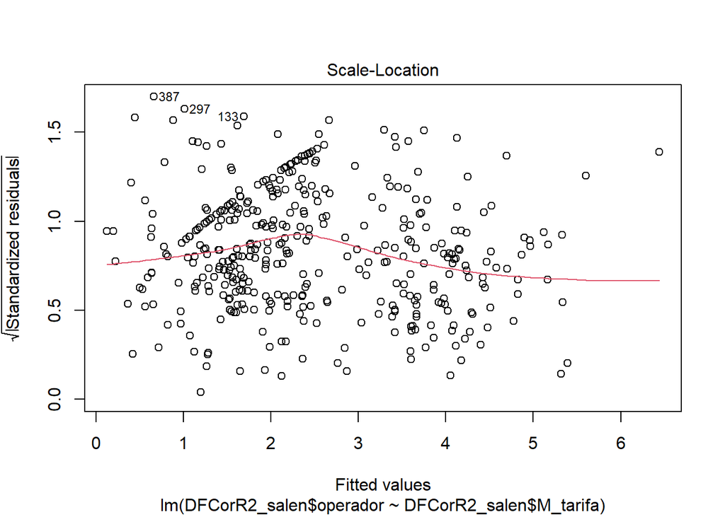

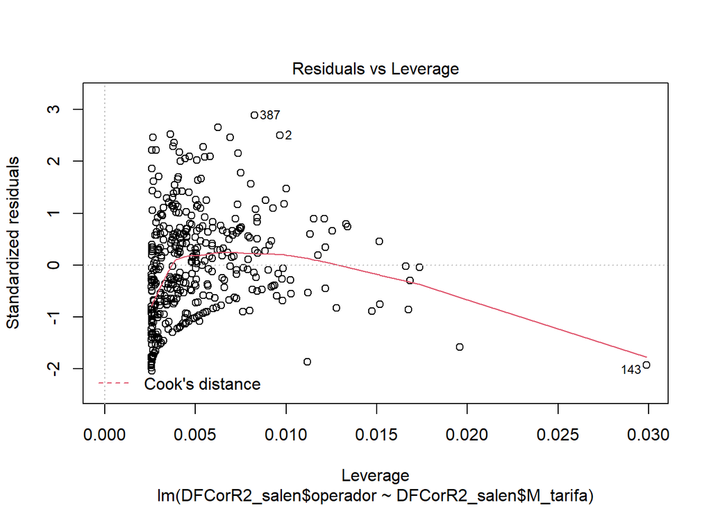

```r
plot(modeloR2)
```

**Regresión 3**

El departamento de marketing quiere obtener un modelo que a partir de la edad de los clientes se pueda generar una aproximación al número de llamadas que realizan por las mañanas. Para ello, haremos una comparación entre el modelo del Data Frame de las personas que abandonan la empresa y el Data Frame de las personas que permanecen en la empresa.

- En la primera parte, partiremos del **Data Frame de las personas que abandonan la empresa**. Primero, el departamento de marketing ha hecho unos cortes en el Data Frame para obtener su población de interés.

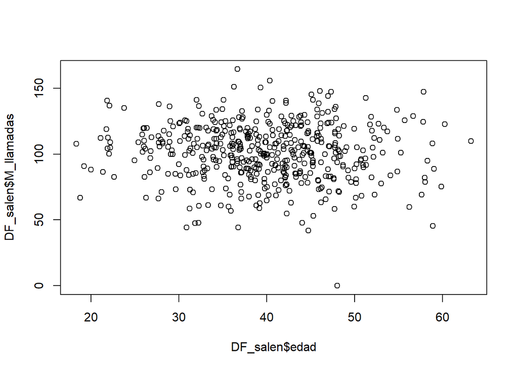

```r
plot(DF_salen$edad, DF_salen$M_llamadas)
```

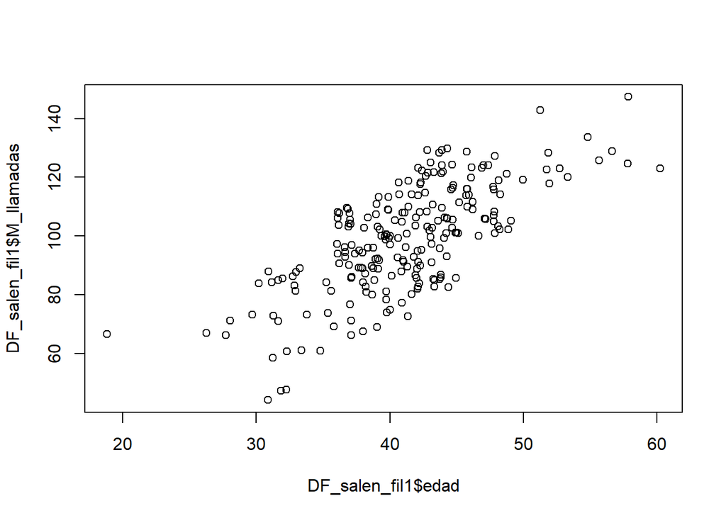

```r
f1<-which((DF_salen$edad>=40) & (DF_salen$M_llamadas<=70))
f2<-which((DF_salen$edad>=45) & (DF_salen$M_llamadas<=100))
f3<-which((DF_salen$edad<=36) & (DF_salen$M_llamadas>=90))
f4<-which((DF_salen$edad<=42) & (DF_salen$M_llamadas>=120))
f5<-which((DF_salen$edad<=50) & (DF_salen$M_llamadas>=130))
f6<-which((DF_salen$edad<=30) & (DF_salen$M_llamadas>=80))
f7<-which((DF_salen$edad>=52) & (DF_salen$M_llamadas<=120))
f8<-which((DF_salen$edad<=39) & (DF_salen$M_llamadas>=110))
f9<-which((DF_salen$edad>=35) & (DF_salen$M_llamadas<=65))
f10<-which((DF_salen$edad>=42) & (DF_salen$M_llamadas<=80))
f11<-which((DF_salen$edad>=50) & (DF_salen$M_llamadas<=110))
DF_salen_fil1<-DF_salen[-c(f1,f2,f3,f4,f5,f6,f7,f8,f9,f10,f11),]
plot(DF_salen_fil1$edad, DF_salen_fil1$M_llamadas)
```

```r
cor(DF_salen_fil1$edad, DF_salen_fil1$M_llamadas)
```

```
## [1] 0.7085483
```

- A partir de los cortes hechos, se ha logrado obtener que las variables tengan un coeficiente de correlación de 0.71 que entra dentro del parámetro de “buena” correlación.
- Ahora, utilizaremos la función lm para poder ajustar un modelo regresión lineal a partir de las variables elegidas y la graficaremos.

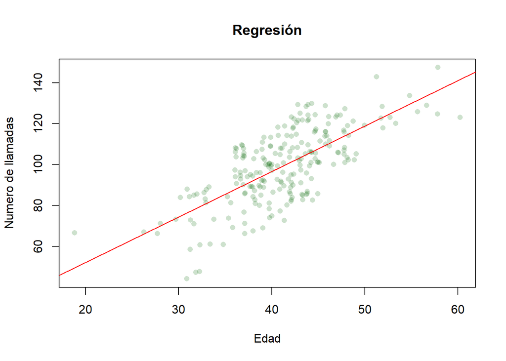

```r
plot(DF_salen_fil1$edad, DF_salen_fil1$M_llamadas, main = "Regresión",col=rgb(0,100,0,50,maxColorValue=255), pch=16, ylab = "Numero de llamadas", xlab = "Edad")
modelo1 <- lm(M_llamadas ~ edad, data = DF_salen_fil1)
abline(modelo1, col = "red")
```

- Posteriormente haremos un summary de donde se extraerá las variables y coeficientes estimados para el intercepto ($\beta_0$) y para la variable ($\beta_1$) para la regresión lineal.

```r
summary(modelo1)
```

```
##
## Call:
## lm(formula = M_llamadas ~ edad, data = DF_salen_fil1)
##
## Residuals:
##     Min      1Q  Median      3Q     Max
## -32.153  -8.337   0.570   9.184  26.588
##
## Coefficients:
##             Estimate Std. Error t value Pr(>|t|)
## (Intercept)   7.7303     6.1357    1.26    0.209
## edad          2.2209     0.1475   15.06   <2e-16 ***
## ---
## Signif. codes:  0 '***' 0.001 '**' 0.01 '*' 0.05 '.' 0.1 ' ' 1
##
## Residual standard error: 12.82 on 225 degrees of freedom
## Multiple R-squared:  0.502,  Adjusted R-squared:  0.4998
## F-statistic: 226.8 on 1 and 225 DF,  p-value: < 2.2e-16
```

- Lo que se obtiene es una regresión entre las variables de M_llamadas (número de llamadas realizadas por la mañana) que es la variable dependiente “y” con la variable edad (la edad de los clientes) que será la variable independiente “x” del Data Frame de las personas que abandonan la empresa.

$$y(x)=\beta_0 + \beta_1x$$

- El R-cuadrado que resulta del modelo es 0.5 por lo que es medianamente bueno el ajuste del modelo lineal. Lo que significa que los datos de la muestra elegida por el departamento de marketing, del Data Frame de las personas que abandonan la empresa, están medianamente cerca de la línea de regresión ajustada.

**Prueba de hipótesis para la validez del modelo**

$$H_{0}:{El~modelo~no~es~válido}$$
$$H_{a}:{El~modelo~es~válido}$$

Rechazamos la hipótesis nula puesto que el p-value es menor que 2.2e-16 por lo que será menor que el α. Como estamos trabajando al 95% de confianza, el valor de α = 0.05. Por ende, el modelo es válido.

**Prueba de hipótesis para verificar el aporte de x**

$$H_{0}:{La~variable~x~no~aporta~al~modelo~propuesto}$$
$$H_{a}:{La~variable~x~aporta~al~modelo~propuesto}$$

Rechazamos la hipótesis nula puesto que el p-value es menor que 2e-16 por lo que será menor que el α. Como estamos trabajando al 95% de confianza, el valor de α = 0.05. Por ende, la variable x aporta al modelo propuesto y existe una relación entre las dos variables del Data Frame de las personas que abandonan la empresa.

- A continuación se realizará un análisis de residuos donde verificaremos si el ajuste lineal hecho es el adecuado.

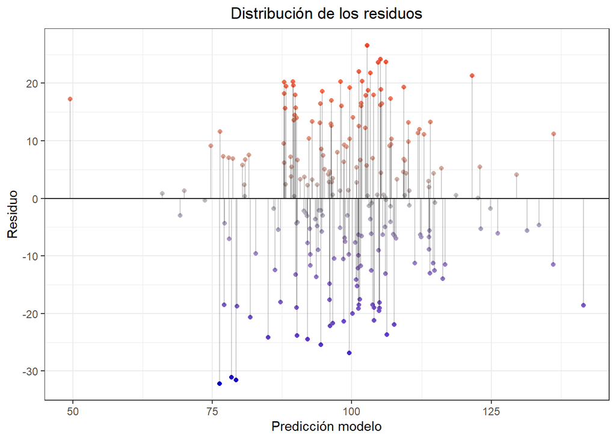

```r
# creamos la base para evaluar los errores
mod1 = data.frame(modelo1$fitted.values, modelo1$residuals)
colnames(mod1) = c("estimadores","residuos")

# Dibujamos
ggplot(data = mod1, aes(x = estimadores, y = residuos)) +
  geom_point(aes(color = residuos)) +
  scale_color_gradient2(low = "blue3", mid = "grey", high = "red") +
  geom_hline(yintercept = 0) +
  geom_segment(aes(xend = estimadores, yend = 0), alpha = 0.2) +
  labs(title = "Distribución de los residuos", x = "Predicción modelo",
       y = "Residuo") +
  theme_bw() +
  theme(plot.title = element_text(hjust = 0.5), legend.position = "none")
```

- Con el gráfico de distribución de residuos podemos observar que los errores no siguen un orden específico por lo que son aleatorios. Además, podemos observar que hay presencia de outliers que pueden afectar la linealidad de nuestro modelo.

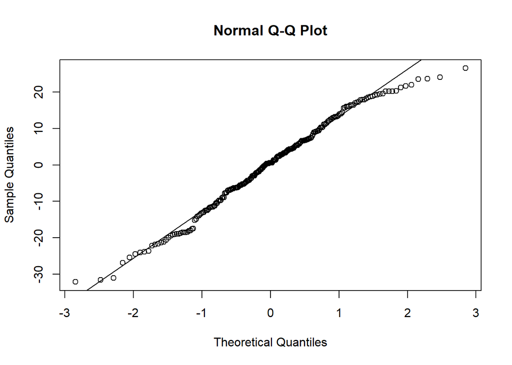

```r
qqnorm(mod1$residuos)
qqline(mod1$residuos)
```

- Del gráfico Q-Q podemos observar el efecto que han causado los outliers, mencionados anteriormente, en la normalidad de los errores. Pero la mayoría de valores de los residuos siguen un comportamiento de normalidad.

Con lo observado en los gráficos mostrados, el departamento de marketing puede aceptar la linealidad del modelo de las variables de M_llamadas y edad del Data Frame de las personas que abandonan la empresa.

- En la segunda parte, partiremos del **Data Frame de las personas que permanecen en la empresa**. Primero, el departamento de marketing ha hecho unos cortes en el Data Frame para obtener su población de interés.

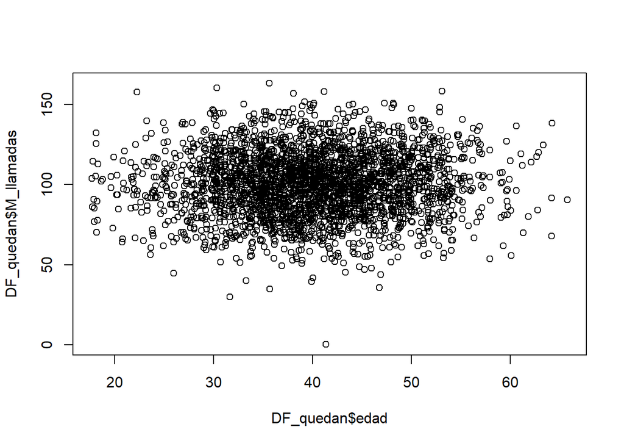

```r
plot(DF_quedan$edad, DF_quedan$M_llamadas)
```

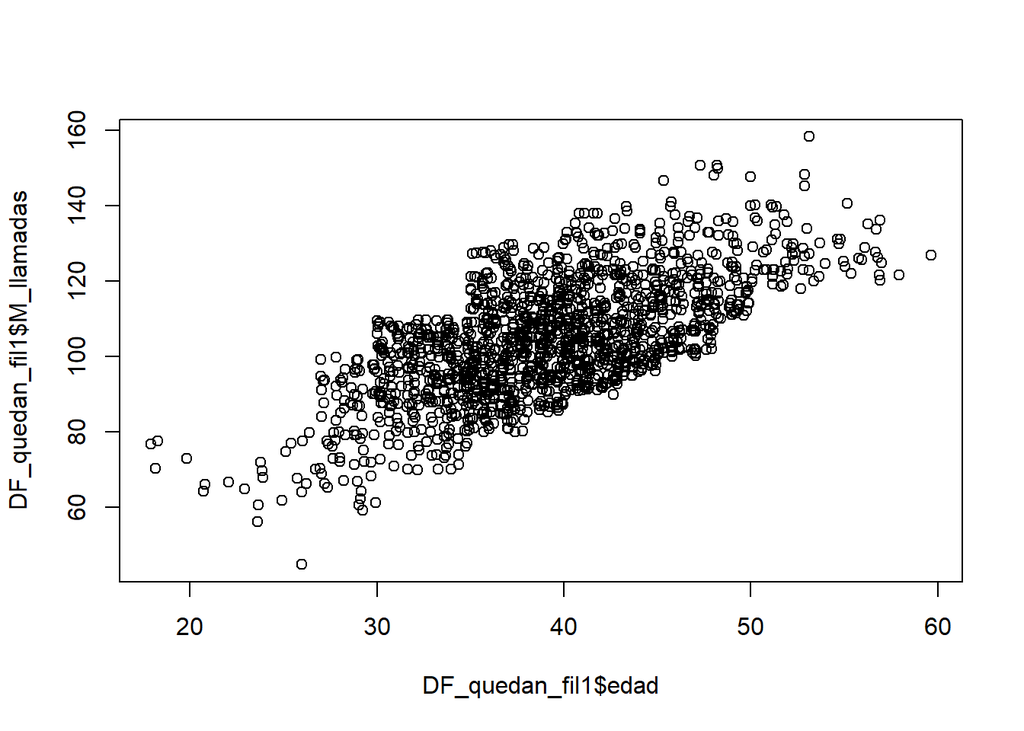

```r
#DF_salen_fil1 <-DF_salen[DF_salen$edad>45 & DF_salen$M_llamadas>30,]
fq1<-which((DF_quedan$edad>=45) & (DF_quedan$M_llamadas<=100))
fq2<-which((DF_quedan$edad>=55) & (DF_quedan$M_llamadas<=120))
fq3<-which((DF_quedan$edad>=40) & (DF_quedan$M_llamadas<=90))
fq4<-which((DF_quedan$edad<=27) & (DF_quedan$M_llamadas>=80))
fq5<-which((DF_quedan$edad<=30) & (DF_quedan$M_llamadas>=100))
fq6<-which((DF_quedan$edad<=40) & (DF_quedan$M_llamadas>=130))
fq7<-which((DF_quedan$edad<=45) & (DF_quedan$M_llamadas>=140))
fq8<-which((DF_quedan$edad<=35) & (DF_quedan$M_llamadas>=110))
fq9<-which((DF_quedan$edad>=55) & (DF_quedan$M_llamadas<=115))
fq10<-which((DF_quedan$edad>=35) & (DF_quedan$M_llamadas<=80))
fq11<-which((DF_quedan$edad>=30) & (DF_quedan$M_llamadas<=70))
fq12<-which((DF_quedan$edad>=50) & (DF_quedan$M_llamadas<=110))
fq13<-which((DF_quedan$edad>=60) & (DF_quedan$M_llamadas<=150))
fq14<-which((DF_quedan$edad>=48) & (DF_quedan$M_llamadas<=110))
fq15<-which((DF_quedan$edad>=43) & (DF_quedan$M_llamadas<=95))
fq16<-which((DF_quedan$edad>=38) & (DF_quedan$M_llamadas<=85))
fq17<-which((DF_quedan$edad>=50) & (DF_quedan$M_llamadas<=118))
DF_quedan_fil1<-DF_quedan[-c(fq1,fq2,fq3,fq4,fq5,fq6,fq7,fq8,fq9,fq10,fq11,fq12,fq13,fq14,fq15,fq16,fq17),]
plot(DF_quedan_fil1$edad, DF_quedan_fil1$M_llamadas)
```

```r
cor(DF_quedan_fil1$edad, DF_quedan_fil1$M_llamadas)
```

```
## [1] 0.6626008
```

- A partir de los cortes hechos, se ha logrado obtener que las variables tengan un coeficiente de correlación de 0.66 que entra dentro del parámetro de “buena” correlación.
- Ahora, utilizaremos la función lm para poder ajustar un modelo regresión lineal a partir de las variables elegidas y la graficaremos.

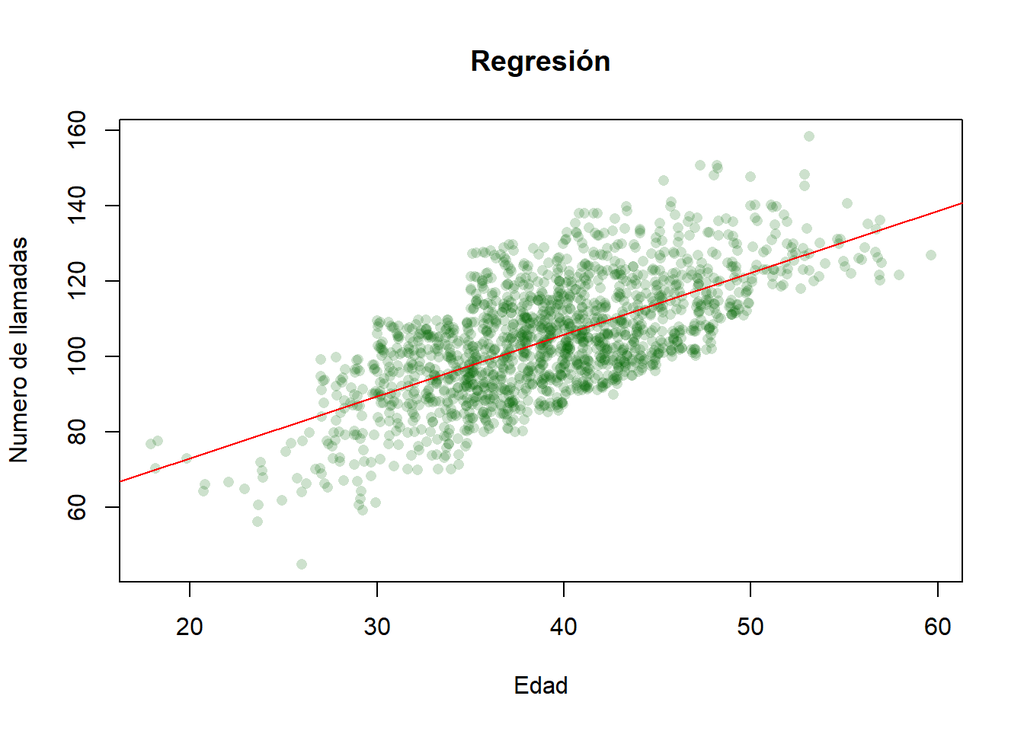

```r
plot(DF_quedan_fil1$edad, DF_quedan_fil1$M_llamadas, main = "Regresión",col=rgb(0,100,0,50,maxColorValue=255), pch=16, ylab = "Numero de llamadas", xlab = "Edad")
modelo2 <- lm(M_llamadas ~ edad, data = DF_quedan_fil1)
abline(modelo2, col = "red")
```

- Posteriormente haremos un summary de donde se extraerá las variables y coeficientes estimados para el intercepto ($\beta_0$) y para la variable ($\beta_1$) para la regresión lineal.

```r
summary(modelo2)
```

```
##
## Call:
## lm(formula = M_llamadas ~ edad, data = DF_quedan_fil1)
##
## Residuals:
##     Min      1Q  Median      3Q     Max
## -38.032  -9.117  -0.787   8.475  32.965
##
## Coefficients:
##             Estimate Std. Error t value Pr(>|t|)
## (Intercept) 40.34834    1.85837   21.71   <2e-16 ***
## edad         1.63933    0.04678   35.04   <2e-16 ***
## ---
## Signif. codes:  0 '***' 0.001 '**' 0.01 '*' 0.05 '.' 0.1 ' ' 1
##
## Residual standard error: 11.59 on 1569 degrees of freedom
## Multiple R-squared:  0.439,  Adjusted R-squared:  0.4387
## F-statistic:  1228 on 1 and 1569 DF,  p-value: < 2.2e-16
```

- Lo que se obtiene es una regresión entre las variables de M_llamadas (número de llamadas realizadas por la mañana) que es la variable dependiente “y” con la variable edad (la edad de los clientes) que será la variable independiente “x” del Data Frame de las personas que permanecen en la empresa.

$$y(x)=\beta_0 + \beta_1x$$

- El R-cuadrado que resulta del modelo es 0.44 por lo que es medianamente bueno el ajuste del modelo lineal. Lo que significa que los datos de la muestra elegida por el departamento de marketing, del Data Frame de las personas que permanecen en la empresa, están medianamente cerca de la línea de regresión ajustada.

**Prueba de hipótesis para la validez del modelo**

$$H_{0}:{El~modelo~no~es~válido}$$
$$H_{a}:{El~modelo~es~válido}$$

Rechazamos la hipótesis nula puesto que el p-value es menor que 2.2e-16 por lo que será menor que el α. Como estamos trabajando al 95% de confianza, el valor de α = 0.05. Por ende, el modelo es válido.

**Prueba de hipótesis para verificar el aporte de x**

$$H_{0}:{La~variable~x~no~aporta~al~modelo~propuesto}$$
$$H_{a}:{La~variable~x~aporta~al~modelo~propuesto}$$

Rechazamos la hipótesis nula puesto que el p-value es menor que 2e-16 por lo que será menor que el α. Como estamos trabajando al 95% de confianza, el valor de α = 0.05. Por ende, la variable x aporta al modelo propuesto y existe una relación entre las dos variables del Data Frame de las personas que permanecen en la empresa.

- A continuación se realizará un análisis de residuos donde verificaremos si el ajuste lineal hecho es el adecuado.

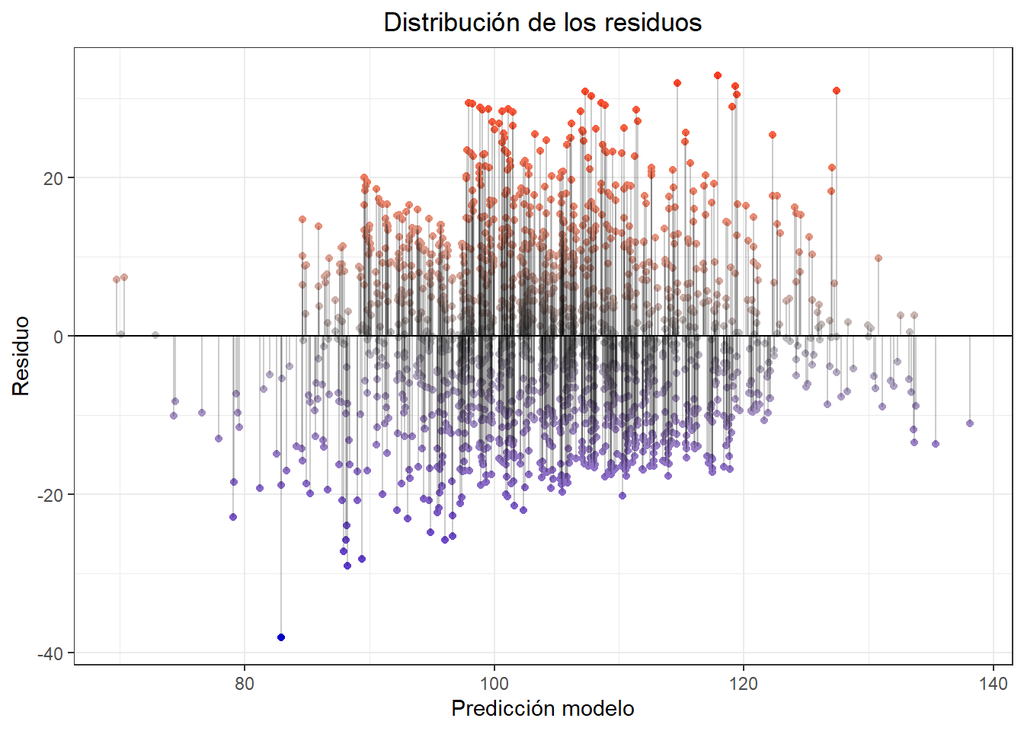

```r
# creamos la base para evaluar los errores
mod2 = data.frame(modelo2$fitted.values, modelo2$residuals)
colnames(mod2) = c("estimadores","residuos")

# Dibujamos
ggplot(data = mod2, aes(x = estimadores, y = residuos)) +
  geom_point(aes(color = residuos)) +
  scale_color_gradient2(low = "blue3", mid = "grey", high = "red") +
  geom_hline(yintercept = 0) +
  geom_segment(aes(xend = estimadores, yend = 0), alpha = 0.2) +
  labs(title = "Distribución de los residuos", x = "Predicción modelo",
       y = "Residuo") +
  theme_bw() +
  theme(plot.title = element_text(hjust = 0.5), legend.position = "none")
```

- Con el gráfico de distribución de residuos podemos observar que los errores no siguen un orden específico por lo que son aleatorios. Además, podemos observar que hay mayor presencia de outliers debido a que el tamaño de este Data Frame es mucho mayor que el de las personas que abandonan la empresa. Estos outliers que pueden afectar la linealidad de nuestro modelo.

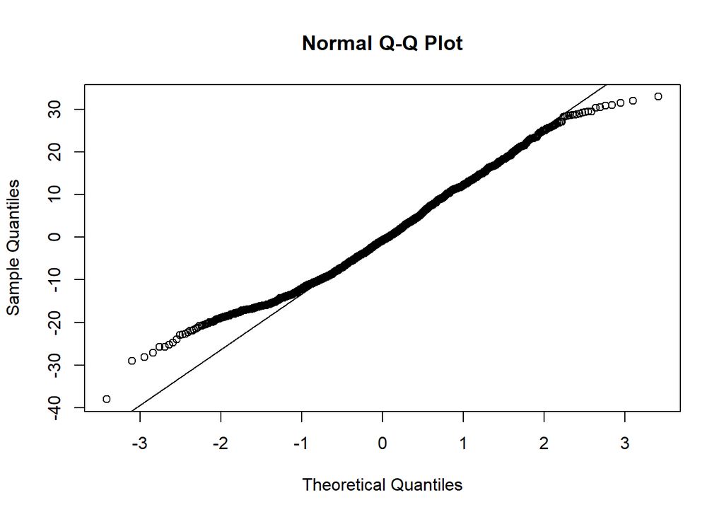

```r
qqnorm(mod2$residuos)
qqline(mod2$residuos)
```

- Del gráfico Q-Q podemos observar el efecto que han causado los outliers, mencionados anteriormente, en la normalidad de los errores. Pero, aún así, la mayoría de valores de los residuos siguen un comportamiento de normalidad.

Con lo observado en los gráficos mostrados, el departamento de marketing puede aceptar la linealidad del modelo de las variables de M_llamadas y edad del Data Frame de las personas que permanecen en la empresa.

**Observaciones generales de la regresión 3**

- Al comparar los valores obtenidos en las respectivas regresiones del Data Frame de las personas que abandonan la empresa y del Data Frame de las personas que permanecen en la empresa, podemos observar que la regresión del Data Frame de las personas que permanecen en la empresa ha sido menos precisa a comparación del otro Data Frame y esto se debe a que el tamaño del Data Frame es mucho más grande por lo que puede haber más outliers que afectan directamente a la normalidad de los residuos que a su vez afectan la linealidad y precisión de la regresión planteada para ese modelo.
- Analizando lo obtenido en la regresión de cada uno de los Data Frame podemos decir que si el departamento de marketing realiza su estudio en otra población, haciendo los cortes respectivos, podría encontrar un mayor coeficiente de correlación entre la variable M_llamadas y la edad. Esto beneficiaría directamente a la linealidad del modelo de regresión que queremos obtener, puesto que la normalidad de los errores sería más evidente.

### **Conclusiones**

Comprobaremos si los objetivos planteados en un inicio se llegan a identificar o comprobar.

**Objetivo general:** * Identificar la cantidad de clientes que se fugan de la empresa en un mes y el comportamiento de los mismos. RESPUESTA - Al filtrar nuestro dara frame para las peronas que fugan de la empresa (DF_salen) identificamos que 483 personas decidieron abandonar la empresa. Además, notamos que las personas que fugan en promedio tienden a realizar una mayor cantidad de llamadas al operador. Creemos que estas llamdas se deben a que tienen algunas quejas respecto al funcionamiento del plan con el que cuentan; por lo que, las llamadas al operador podrían ser un indicador que la emprea AT&T debería revisar para predecir la posible fuga de un cliente y poder evitarla.

**Objetivos específicos:**

- Conocer si existe una relación entre la cantidad de minutos totales que duran las llamadas y el momento del día en el que se realizan (mañana, tarde, noche). RESPUESTA
- Se identificó que las llamadas duran en promedio más en la tarde y noche que en la mañana, con una media de 201.4, 201.2 y 179.4. Esto se puede deber a que las personas durante la mañana se encuentran trabajando, estudiando o realizando los quehaceres del hogar y en el resto del día (tarde y noche) se encuentran un poco más libres.
- Identificar si existe una relación entre la cantidad de minutos/llamadas realizadas a servicio al cliente y la fuga de los mismos. RESPUESTA
- Efectivamente existe una relación entre el número de llamadas al operador y los clientes que se fugan. Ellos realizan en promedio casi el doble de llamadas al operador que las personas que permanecen en la empresa.
- Identificar si existe una relación entre la tarifa que pagan los clientes y la fuga de los mismos. RESPUESTA
- En el horario de la mañana notamos que las personas que abandonan la empresa pagan una mayor tarifa que las personas que se queda. Esto podría ser una razón por la que los clientes decidieron fugarse. Quizá la empresa debería reajustar el costo de las llamadas.
- Identificar si existe una relación entre la cantidad de minutos/llamadas que realizan los clientes a cualquier hora del día (mañana, tarde, noche) y la fuga de los mismos. RESPUESTA -Notamos que no existe mucha variación entre la cantidad de llamadas que realizan las personas que se fugan y las que no; por lo que no consideramos sea un aspecto que deba revisar la empresa.
- Identificar el estado o zona (norte, sur, este, oeste) que tiene mayor cantidad de fuga de clientes. RESPUESTA
- Pudimos identificar que la zona en la que había una mayor fuga por parte de los clientes era la Zona Noreste. Específicamente identificamos que el estado con mayor fuga de clientes es New Jersey. Creemos que esto se puede deber a que no hay muy buena señal en esta zona de estados unidos por lo que recomendamos a la empresa revisar sus antenas o su cableado.

**Conclusión adicional** - Encontramos la relación de la edad con el número de llamadas que realiza en la mañana encontramos que según el estudio realizado es positiva .El número de minutos que realizan según la edad del estudio realizado por el sector de marketing notamos que esta es negativa según lo graficado.